# Visual patterns test analysis

# The study

### Familiarization phase

Participants see 5 stimuli repeated 8 times each. Stimuli consist of a 3x3 grid, with 5 random shapes (circle,triangle,square) placed randomly (any 9 cells) with random color (red,blue,yellow,green,orange,purple).

### Study phase

Participants see the 5 familiar stimuli 5 times each (25) and 50 novel stimuli. They have to judge if the current stimulus is one of the familiars. The novels differ to a differing degree from the familiars: there is 5x2 (two for each familiar) that is wholly different (diffarr). 5x2 that has the same placement of random shapes (sarr), 5x2 same arrangement and shapes (sarrsha), 5x2 same arrangement and colors (sarrcol) 5x2 same arrangement, shapes and colors (colors are randomized, thus, these are not the same as the familiars - sarrshacol).

### Test phase

Participants see the novels from the study phase and 50 new stimuli (sarr - 10, sarrsha - 10, etc.). Participants have to signal if they have already seen the current stimulus or it is wholly new. They had the option to signal “maybe”, but were asked to do this in moderation (maybe resp <= 20). These responses have been added to correct responses.

## Participants

The online task has been started by a total of 69 participants.

We also excluded some (1) participants as they missed more than 66.3065823 trials (mean + 2*sd of misses by participant).

We also excluded those who recognized less than half of the prototypes in the study phase (14). [inactive - this would drop 14 participants]

Maybe responses [mean(±sd)] : 10.1463415 ± 7.0588986

The sample had a mean(±sd) age of 23.025641 ± 4.8530358.

The histogram below shows the number of participants completing the task in a given hour of the day.

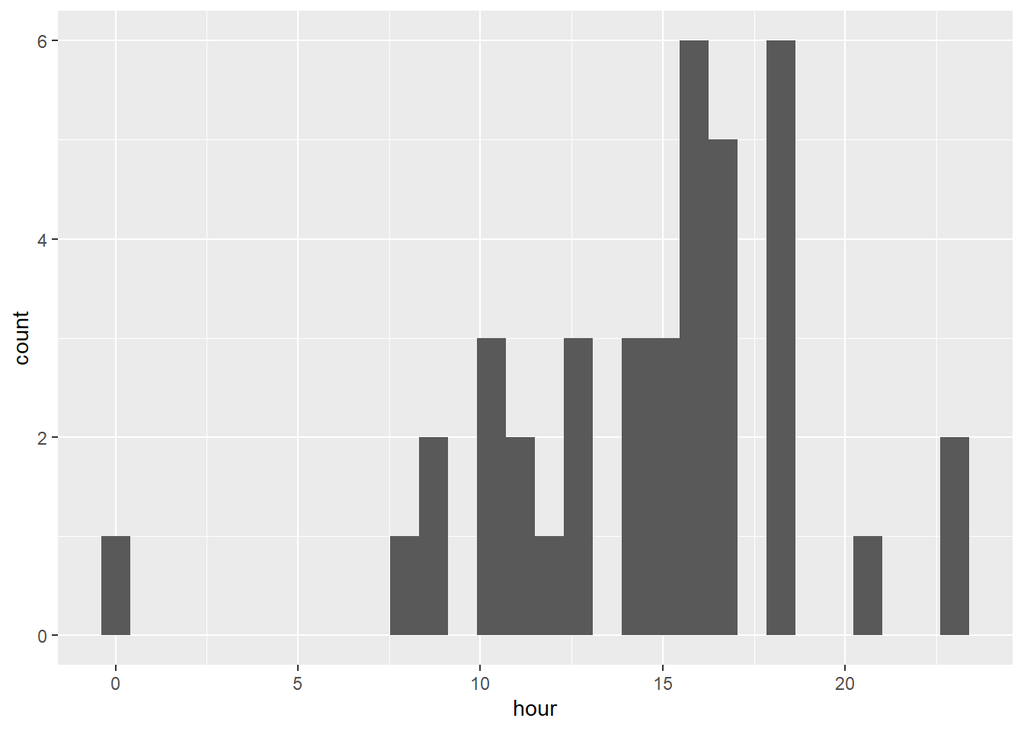

## Study phase:

During the study phase, the participants see familiar and novel items.

The original sample of 41 participants produced a mean (±sd) recognition rate of 0.7121951 ± 0.1012796 for familiar pictures.

The sample performed above chance levels, as a one sample t-test showed (t(40)=13.4154508, p = 2.154104610^{-16}, Cohen’s d = 2.0951414, 95% CI:1.3095359 - 2.880747).

We use an ANOVA to see if there is a difference in correct rejection for the different novels.

```
## Anova Table (Type 3 tests)
##
## Response: crrate
##   Effect           df  MSE         F  ges p.value
## 1   type 3.52, 140.77 0.02 16.07 *** .125   <.001
## ---
## Signif. codes:  0 '***' 0.001 '**' 0.01 '*' 0.05 '+' 0.1 ' ' 1
##
## Sphericity correction method: GG
```

```
##  contrast             estimate     SE  df t.ratio p.value
##  diffarr - sarr        0.13171 0.0288 160  4.569  0.0001
##  diffarr - sarrcol     0.12439 0.0288 160  4.316  0.0003
##  diffarr - sarrsha     0.22927 0.0288 160  7.954  <.0001
##  diffarr - sarrshacol  0.10488 0.0288 160  3.639  0.0034
##  sarr - sarrcol       -0.00732 0.0288 160 -0.254  0.9991
##  sarr - sarrsha        0.09756 0.0288 160  3.385  0.0079
##  sarr - sarrshacol    -0.02683 0.0288 160 -0.931  0.8846
##  sarrcol - sarrsha     0.10488 0.0288 160  3.639  0.0034
##  sarrcol - sarrshacol -0.01951 0.0288 160 -0.677  0.9612
##  sarrsha - sarrshacol -0.12439 0.0288 160 -4.316  0.0003
##
## P value adjustment: tukey method for comparing a family of 5 estimates
```

```
##  contrast  estimate     SE  df t.ratio p.value
##  linear     -0.3073 0.0645 160 -4.768  <.0001
##  quadratic   0.4000 0.0763 160  5.245  <.0001
##  cubic       0.0902 0.0645 160  1.400  0.1634
##  quartic     0.5927 0.1705 160  3.476  0.0007
```

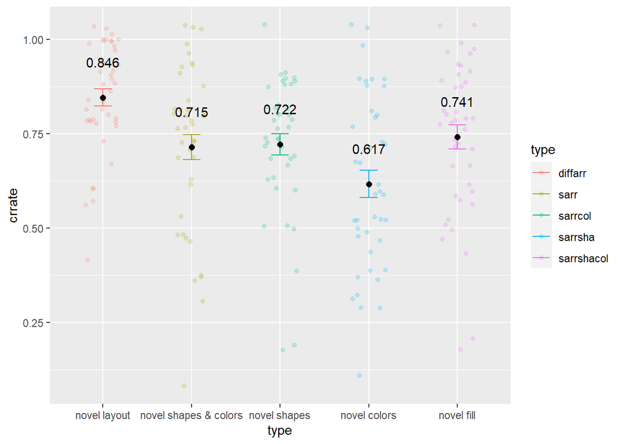

## Test phase:

```
## [1] "A t-test to compare the number of old responses btwn old and new stim"
```

```
##
##  Paired t-test
##
## data:  a and b
## t = 1.908, df = 44, p-value = 0.06293
## alternative hypothesis: true difference in means is not equal to 0
## 95 percent confidence interval:
##  -0.06000358  2.19333691
## sample estimates:
## mean of the differences
##                1.066667
```

```
##
## Cohen's d
##
## d estimate: 0.1349974 (negligible)
## 95 percent confidence interval:
##        lower        upper
## -0.006246653  0.276241431
```

```
##
##  Shapiro-Wilk normality test
##
## data:  d
## W = 0.97579, p-value = 0.4603
```

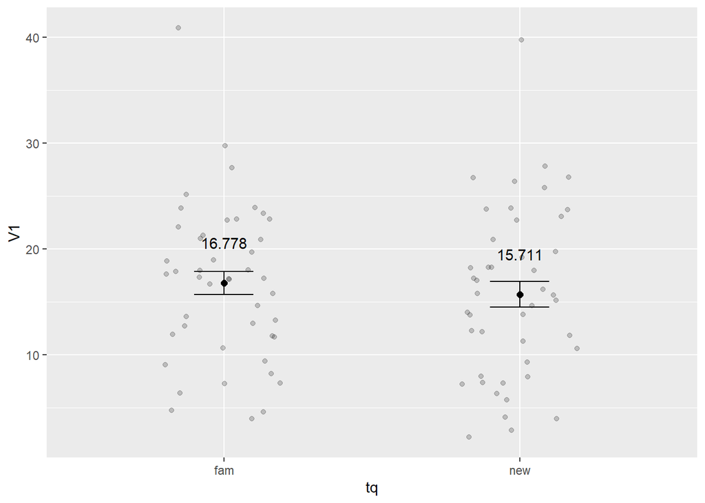

```
## [1] "ANOVA with correct recognition minus false alarm by category"
```

```
## Anova Table (Type 3 tests)
##
## Response: CorrectedRecognitions
##   Effect           df  MSE       F  ges p.value
## 1   type 3.78, 151.13 3.42 4.80 ** .089    .001
## ---
## Signif. codes:  0 '***' 0.001 '**' 0.01 '*' 0.05 '+' 0.1 ' ' 1
##
## Sphericity correction method: GG
```

```
##  contrast             estimate    SE  df t.ratio p.value
##  diffarr - sarr          0.195 0.397 160  0.492  0.9881
##  diffarr - sarrcol       1.049 0.397 160  2.642  0.0676
##  diffarr - sarrsha       0.390 0.397 160  0.983  0.8626
##  diffarr - sarrshacol    1.463 0.397 160  3.687  0.0028
##  sarr - sarrcol          0.854 0.397 160  2.151  0.2042
##  sarr - sarrsha          0.195 0.397 160  0.492  0.9881
##  sarr - sarrshacol       1.268 0.397 160  3.195  0.0143
##  sarrcol - sarrsha      -0.659 0.397 160 -1.659  0.4622
##  sarrcol - sarrshacol    0.415 0.397 160  1.045  0.8341
##  sarrsha - sarrshacol    1.073 0.397 160  2.704  0.0578
##
## P value adjustment: tukey method for comparing a family of 5 estimates
```

```
##  contrast  estimate    SE  df t.ratio p.value
##  linear      -3.122 0.888 160 -3.517  0.0006
##  quadratic   -0.244 1.050 160 -0.232  0.8166
##  cubic       -1.073 0.888 160 -1.209  0.2284
##  quartic     -5.415 2.348 160 -2.306  0.0224
```

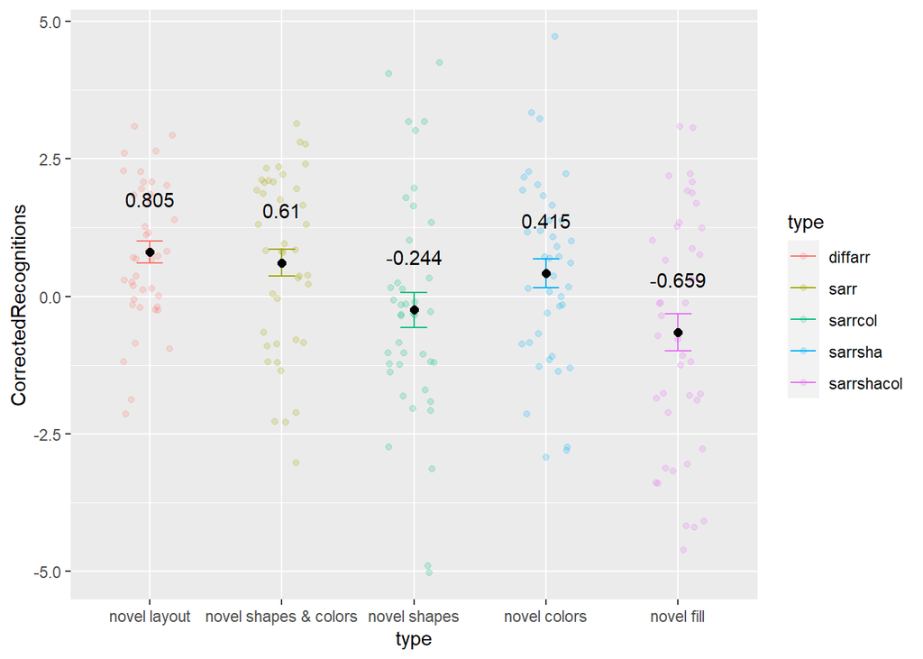

```
## [1] "ANOVA with correct rejection minus false alarm by category"
```

```
## Anova Table (Type 3 tests)
##
## Response: CorrectedRejections
##   Effect           df  MSE        F  ges p.value
## 1   type 3.58, 143.14 3.83 6.11 *** .112   <.001
## ---
## Signif. codes:  0 '***' 0.001 '**' 0.01 '*' 0.05 '+' 0.1 ' ' 1
##
## Sphericity correction method: GG
```

```
##  contrast             estimate    SE  df t.ratio p.value
##  diffarr - sarr          0.780 0.409 160  1.910  0.3161
##  diffarr - sarrcol       1.463 0.409 160  3.582  0.0041
##  diffarr - sarrsha       1.146 0.409 160  2.806  0.0442
##  diffarr - sarrshacol    1.878 0.409 160  4.597  0.0001
##  sarr - sarrcol          0.683 0.409 160  1.672  0.4545
##  sarr - sarrsha          0.366 0.409 160  0.895  0.8982
##  sarr - sarrshacol       1.098 0.409 160  2.686  0.0604
##  sarrcol - sarrsha      -0.317 0.409 160 -0.776  0.9372
##  sarrcol - sarrshacol    0.415 0.409 160  1.015  0.8482
##  sarrsha - sarrshacol    0.732 0.409 160  1.791  0.3825
##
## P value adjustment: tukey method for comparing a family of 5 estimates
```

```
##  contrast  estimate    SE  df t.ratio p.value
##  linear       -4.12 0.914 160 -4.512  <.0001
##  quadratic     1.10 1.081 160  1.015  0.3115
##  cubic        -1.15 0.914 160 -1.255  0.2114
##  quartic      -2.95 2.417 160 -1.221  0.2239
```

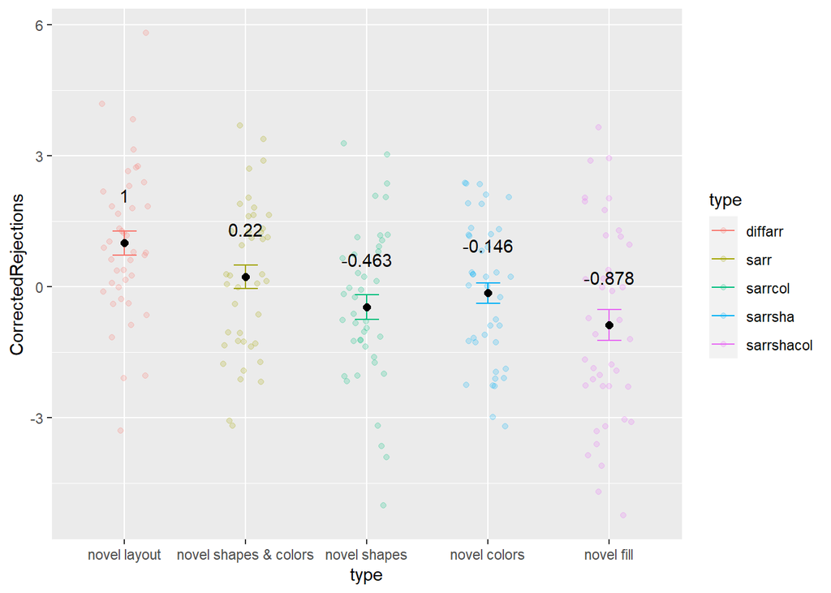

```
## [1] "ANOVA with corrected differentiation score by category ((crecog-fa)+(creject-fa))"
```

```
## Anova Table (Type 3 tests)
##
## Response: OCCategorizations
##   Effect           df   MSE        F  ges p.value
## 1   type 3.61, 144.39 12.11 6.37 *** .115   <.001
## ---
## Signif. codes:  0 '***' 0.001 '**' 0.01 '*' 0.05 '+' 0.1 ' ' 1
##
## Sphericity correction method: GG
```

```
##  contrast             estimate   SE  df t.ratio p.value
##  diffarr - sarr          0.976 0.73 160  1.336  0.6692
##  diffarr - sarrcol       2.512 0.73 160  3.440  0.0066
##  diffarr - sarrsha       1.537 0.73 160  2.104  0.2234
##  diffarr - sarrshacol    3.341 0.73 160  4.576  0.0001
##  sarr - sarrcol          1.537 0.73 160  2.104  0.2234
##  sarr - sarrsha          0.561 0.73 160  0.768  0.9394
##  sarr - sarrshacol       2.366 0.73 160  3.240  0.0125
##  sarrcol - sarrsha      -0.976 0.73 160 -1.336  0.6692
##  sarrcol - sarrshacol    0.829 0.73 160  1.136  0.7874
##  sarrsha - sarrshacol    1.805 0.73 160  2.472  0.1023
##
## P value adjustment: tukey method for comparing a family of 5 estimates
```

```
##  contrast  estimate   SE  df t.ratio p.value
##  linear      -7.244 1.63 160 -4.436  <.0001
##  quadratic    0.854 1.93 160  0.442  0.6592
##  cubic       -2.220 1.63 160 -1.359  0.1760
##  quartic     -8.366 4.32 160 -1.936  0.0546
```

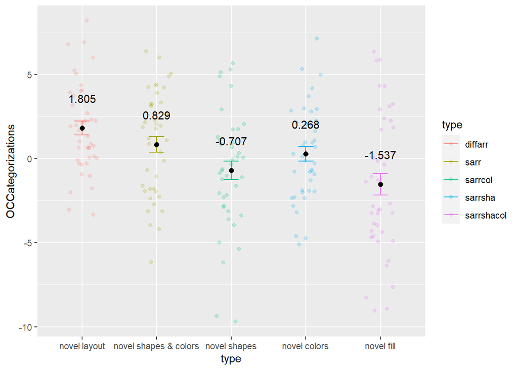

# Mixed models

## The metrics

### DTF - Difference To corresponding Familiar picture

All pictures are compared to a familiar. The number of differences between the three vectors of the pictures yields a difference score.

### DTAF - mean Difference To All Familiars

We calculate the difference from all prototypes and take the mean for each picture in the set.

### DTAN - mean Difference To All other Novels in the same category

We calculate the differences between each pair of pictures and then take the mean of these differences (19 comparisons per stim).

### DTN_byPhase - mean Difference to Novels in the same category per study/test phase

We calculate the differences between each pair of pictures and then take the mean of these differences (9 comparisons per stim).

### DTPPm - mean Diff To Previously seen Pictures

We compare the current picture to all previously seen pictures (25 in first study trial, 26 in 2nd, and so on ..). We take the mean.

## Study phase

```
## Generalized linear mixed model fit by maximum likelihood (Laplace
##   Approximation) [glmerMod]
##  Family: binomial  ( logit )
## Formula: st_corr ~ factor(type) + (1 | workerId)
##    Data: stlmm
##
##      AIC      BIC   logLik deviance df.resid
##   3489.3   3531.5  -1737.6   3475.3     3068
##
## Scaled residuals:
##     Min      1Q  Median      3Q     Max
## -3.0884 -1.0430  0.4995  0.6362  1.5349
##
## Random effects:
##  Groups   Name        Variance Std.Dev.
##  workerId (Intercept) 0.2942   0.5424
## Number of obs: 3075, groups:  workerId, 41
##
## Fixed effects:
##                        Estimate Std. Error z value Pr(>|z|)
## (Intercept)              1.8038     0.1638  11.015  < 2e-16 ***
## factor(type)prototype   -0.8394     0.1563  -5.371 7.83e-08 ***
## factor(type)sarr        -0.8268     0.1789  -4.622 3.80e-06 ***
## factor(type)sarrcol     -0.7886     0.1794  -4.395 1.11e-05 ***
## factor(type)sarrsha     -1.2948     0.1745  -7.420 1.17e-13 ***
## factor(type)sarrshacol  -0.6836     0.1810  -3.777 0.000159 ***
## ---
## Signif. codes:  0 '***' 0.001 '**' 0.01 '*' 0.05 '.' 0.1 ' ' 1
##
## Correlation of Fixed Effects:
##                 (Intr) fctr(typ)p factr(typ)srr fctr(typ)srrc factr(typ)srrsh
## fctr(typ)pr     -0.761
## factr(typ)srr   -0.665  0.694
## fctr(typ)srrc   -0.663  0.692      0.605
## factr(typ)srrsh -0.684  0.713      0.623         0.621
## fctr(typ)srrshc -0.656  0.686      0.599         0.598         0.615
```

```
## Package `effects` is not available, but needed for `ggeffect()`. Either install package `effects`, or use `ggpredict()`. Calling `ggpredict()` now.FALSE
```

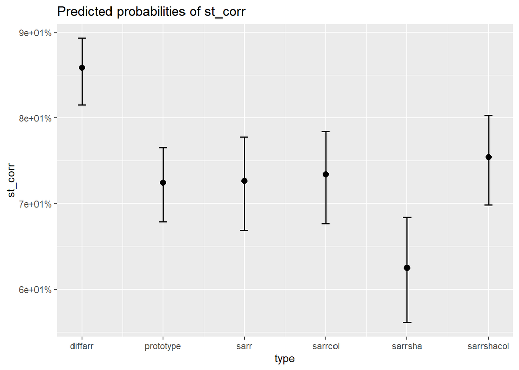

```
## Generalized linear mixed model fit by maximum likelihood (Laplace
##   Approximation) [glmerMod]
##  Family: binomial  ( logit )
## Formula: st_corr ~ DTF + (1 | workerId)
##    Data: stlmm
##
##      AIC      BIC   logLik deviance df.resid
##   3507.4   3525.5  -1750.7   3501.4     3072
##
## Scaled residuals:
##     Min      1Q  Median      3Q     Max
## -3.0542 -1.1059  0.5144  0.6380  1.3072
##
## Random effects:
##  Groups   Name        Variance Std.Dev.
##  workerId (Intercept) 0.2884   0.537
## Number of obs: 3075, groups:  workerId, 41
##
## Fixed effects:
##             Estimate Std. Error z value Pr(>|z|)
## (Intercept) 0.814009   0.099818   8.155 3.49e-16 ***
## DTF         0.048212   0.008483   5.684 1.32e-08 ***
## ---
## Signif. codes:  0 '***' 0.001 '**' 0.01 '*' 0.05 '.' 0.1 ' ' 1
##
## Correlation of Fixed Effects:
##     (Intr)
## DTF -0.332
```

```
## Package `effects` is not available, but needed for `ggeffect()`. Either install package `effects`, or use `ggpredict()`. Calling `ggpredict()` now.FALSE
```

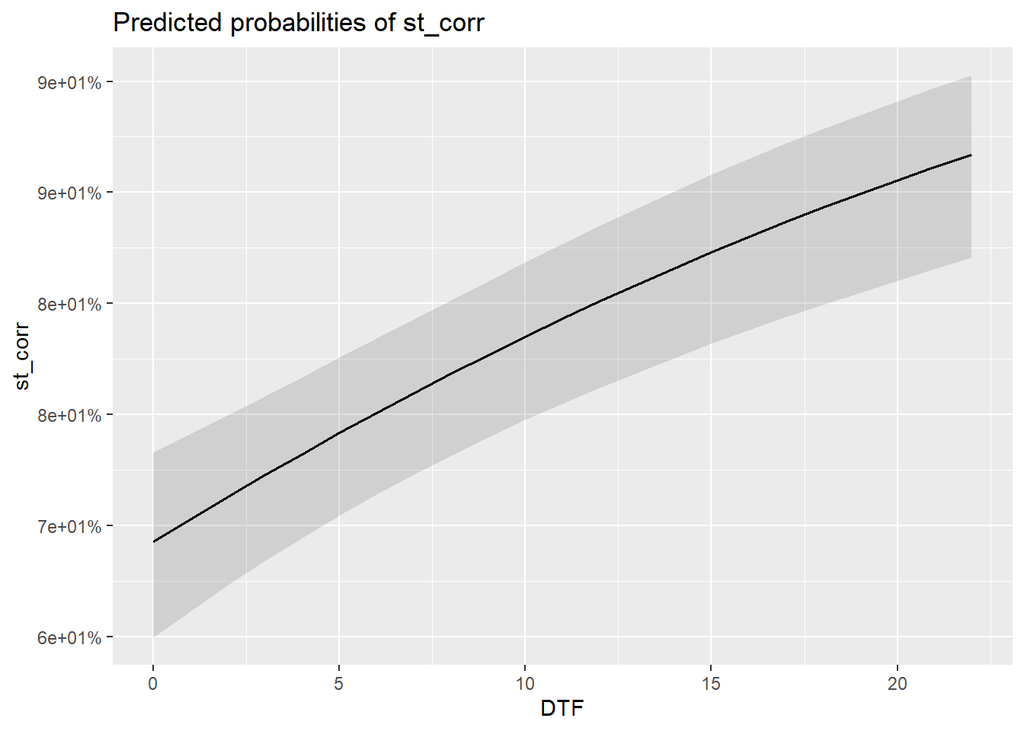

```
## Generalized linear mixed model fit by maximum likelihood (Laplace
##   Approximation) [glmerMod]
##  Family: binomial  ( logit )
## Formula: st_corr ~ DTAF + (1 | workerId)
##    Data: stlmm
##
##      AIC      BIC   logLik deviance df.resid
##   3531.3   3549.4  -1762.7   3525.3     3072
##
## Scaled residuals:
##     Min      1Q  Median      3Q     Max
## -3.1452 -1.1242  0.5137  0.6287  1.2801
##
## Random effects:
##  Groups   Name        Variance Std.Dev.
##  workerId (Intercept) 0.2834   0.5324
## Number of obs: 3075, groups:  workerId, 41
##
## Fixed effects:
##             Estimate Std. Error z value Pr(>|z|)
## (Intercept) 0.841078   0.106812   7.874 3.42e-15 ***
## DTAF        0.021060   0.006309   3.338 0.000844 ***
## ---
## Signif. codes:  0 '***' 0.001 '**' 0.01 '*' 0.05 '.' 0.1 ' ' 1
##
## Correlation of Fixed Effects:
##      (Intr)
## DTAF -0.484
```

```
## Package `effects` is not available, but needed for `ggeffect()`. Either install package `effects`, or use `ggpredict()`. Calling `ggpredict()` now.FALSE
```

```
## Data were 'prettified'. Consider using `terms="DTAF [all]"` to get smooth plots.
```

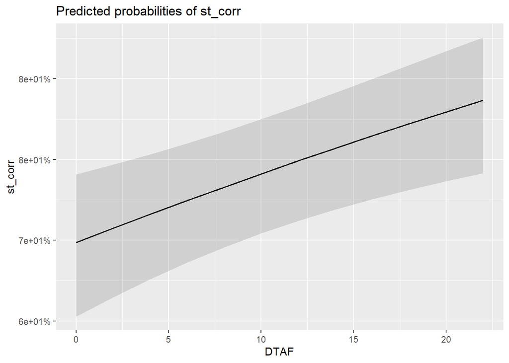

```
## Generalized linear mixed model fit by maximum likelihood (Laplace
##   Approximation) [glmerMod]
##  Family: binomial  ( logit )
## Formula: st_corr ~ DTAN + (1 | workerId)
##    Data: stlmm
##
##      AIC      BIC   logLik deviance df.resid
##   3536.1   3554.1  -1765.0   3530.1     3072
##
## Scaled residuals:
##     Min      1Q  Median      3Q     Max
## -3.1308 -1.1459  0.5139  0.6285  1.2548
##
## Random effects:
##  Groups   Name        Variance Std.Dev.
##  workerId (Intercept) 0.2824   0.5314
## Number of obs: 3075, groups:  workerId, 41
##
## Fixed effects:
##             Estimate Std. Error z value Pr(>|z|)
## (Intercept) 0.878098   0.107892   8.139    4e-16 ***
## DTAN        0.016667   0.006571   2.536   0.0112 *
## ---
## Signif. codes:  0 '***' 0.001 '**' 0.01 '*' 0.05 '.' 0.1 ' ' 1
##
## Correlation of Fixed Effects:
##      (Intr)
## DTAN -0.502
```

```
## Package `effects` is not available, but needed for `ggeffect()`. Either install package `effects`, or use `ggpredict()`. Calling `ggpredict()` now.FALSE
```

```
## Data were 'prettified'. Consider using `terms="DTAN [all]"` to get smooth plots.
```

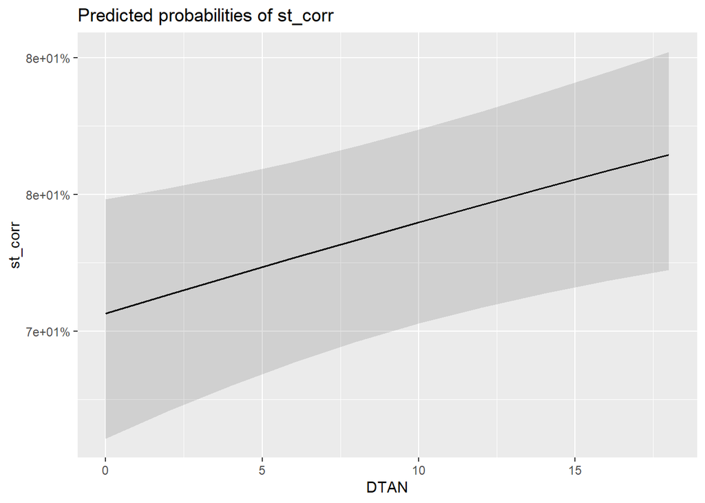

```
## Generalized linear mixed model fit by maximum likelihood (Laplace
##   Approximation) [glmerMod]
##  Family: binomial  ( logit )
## Formula: st_corr ~ DTN_byPhase + (1 | workerId)
##    Data: stlmm
##
##      AIC      BIC   logLik deviance df.resid
##   3536.1   3554.2  -1765.0   3530.1     3072
##
## Scaled residuals:
##     Min      1Q  Median      3Q     Max
## -3.1296 -1.1459  0.5136  0.6285  1.2548
##
## Random effects:
##  Groups   Name        Variance Std.Dev.
##  workerId (Intercept) 0.2824   0.5314
## Number of obs: 3075, groups:  workerId, 41
##
## Fixed effects:
##             Estimate Std. Error z value Pr(>|z|)
## (Intercept) 0.878118   0.107948   8.135 4.13e-16 ***
## DTN_byPhase 0.016096   0.006359   2.531   0.0114 *
## ---
## Signif. codes:  0 '***' 0.001 '**' 0.01 '*' 0.05 '.' 0.1 ' ' 1
##
## Correlation of Fixed Effects:
##             (Intr)
## DTN_byPhase -0.503
```

```
## Package `effects` is not available, but needed for `ggeffect()`. Either install package `effects`, or use `ggpredict()`. Calling `ggpredict()` now.FALSE
```

```
## Data were 'prettified'. Consider using `terms="DTN_byPhase [all]"` to get smooth plots.
```

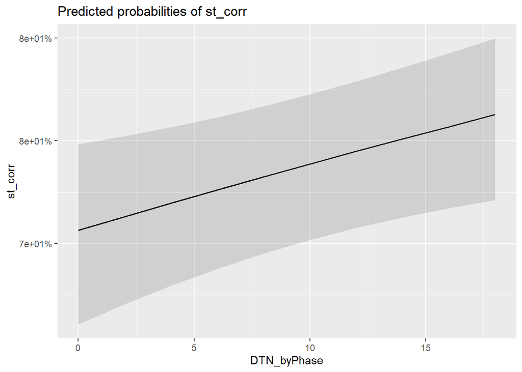

```
## Generalized linear mixed model fit by maximum likelihood (Laplace
##   Approximation) [glmerMod]
##  Family: binomial  ( logit )
## Formula: st_corr ~ DTPPm + (1 | workerId)
##    Data: stlmm
##
##      AIC      BIC   logLik deviance df.resid
##   3493.6   3511.7  -1743.8   3487.6     3072
##
## Scaled residuals:
##     Min      1Q  Median      3Q     Max
## -3.2388 -1.0829  0.5099  0.6345  1.3668
##
## Random effects:
##  Groups   Name        Variance Std.Dev.
##  workerId (Intercept) 0.2913   0.5397
## Number of obs: 3075, groups:  workerId, 41
##
## Fixed effects:
##             Estimate Std. Error z value Pr(>|z|)
## (Intercept)  -0.6638     0.2672  -2.484    0.013 *
## DTPPm         0.1348     0.0203   6.641 3.11e-11 ***
## ---
## Signif. codes:  0 '***' 0.001 '**' 0.01 '*' 0.05 '.' 0.1 ' ' 1
##
## Correlation of Fixed Effects:
##       (Intr)
## DTPPm -0.935
```

```
## Package `effects` is not available, but needed for `ggeffect()`. Either install package `effects`, or use `ggpredict()`. Calling `ggpredict()` now.FALSE
```

```
## Data were 'prettified'. Consider using `terms="DTPPm [all]"` to get smooth plots.
```

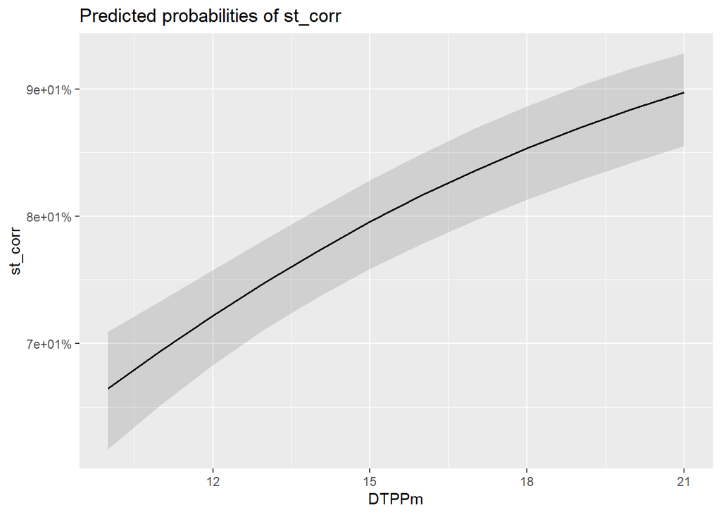

|  | st_corr |  |  |  | st_corr |  |  |  | st_corr |  |  |  | st_corr |  |  |  | st_corr |  |  |  | st_corr |  |  |  |
| --- | --- | --- | --- | --- | --- | --- | --- | --- | --- | --- | --- | --- | --- | --- | --- | --- | --- | --- | --- | --- | --- | --- | --- | --- |
| Predictors | Log-Odds | std. Error | CI | p | Log-Odds | std. Error | CI | p | Log-Odds | std. Error | CI | p | Log-Odds | std. Error | CI | p | Log-Odds | std. Error | CI | p | Log-Odds | std. Error | CI | p |
| (Intercept) | 1.80 | 0.16 | 1.48 – 2.12 | **<0.001** | 0.81 | 0.10 | 0.62 – 1.01 | **<0.001** | 0.84 | 0.11 | 0.63 – 1.05 | **<0.001** | 0.88 | 0.11 | 0.67 – 1.09 | **<0.001** | 0.88 | 0.11 | 0.67 – 1.09 | **<0.001** | -0.66 | 0.27 | -1.19 – -0.14 | **0.013** |
| type [prototype] | -0.84 | 0.16 | -1.15 – -0.53 | **<0.001** |  |  |  |  |  |  |  |  |  |  |  |  |  |  |  |  |  |  |  |  |
| type [sarr] | -0.83 | 0.18 | -1.18 – -0.48 | **<0.001** |  |  |  |  |  |  |  |  |  |  |  |  |  |  |  |  |  |  |  |  |
| type [sarrcol] | -0.79 | 0.18 | -1.14 – -0.44 | **<0.001** |  |  |  |  |  |  |  |  |  |  |  |  |  |  |  |  |  |  |  |  |
| type [sarrsha] | -1.29 | 0.17 | -1.64 – -0.95 | **<0.001** |  |  |  |  |  |  |  |  |  |  |  |  |  |  |  |  |  |  |  |  |
| type [sarrshacol] | -0.68 | 0.18 | -1.04 – -0.33 | **<0.001** |  |  |  |  |  |  |  |  |  |  |  |  |  |  |  |  |  |  |  |  |
| DTF |  |  |  |  | 0.05 | 0.01 | 0.03 – 0.06 | **<0.001** |  |  |  |  |  |  |  |  |  |  |  |  |  |  |  |  |
| DTAF |  |  |  |  |  |  |  |  | 0.02 | 0.01 | 0.01 – 0.03 | **0.001** |  |  |  |  |  |  |  |  |  |  |  |  |
| DTAN |  |  |  |  |  |  |  |  |  |  |  |  | 0.02 | 0.01 | 0.00 – 0.03 | **0.011** |  |  |  |  |  |  |  |  |
| DTN_byPhase |  |  |  |  |  |  |  |  |  |  |  |  |  |  |  |  | 0.02 | 0.01 | 0.00 – 0.03 | **0.011** |  |  |  |  |
| DTPPm |  |  |  |  |  |  |  |  |  |  |  |  |  |  |  |  |  |  |  |  | 0.13 | 0.02 | 0.10 – 0.17 | **<0.001** |
| Random Effects |  |  |  |  |  |  |  |  |  |  |  |  |  |  |  |  |  |  |  |  |  |  |  |  |
| σ<sup>2</sup> | 3.29 |  |  |  | 3.29 |  |  |  | 3.29 |  |  |  | 3.29 |  |  |  | 3.29 |  |  |  | 3.29 |  |  |  |
| τ<sub>00</sub> | 0.29 <sub>workerId</sub> |  |  |  | 0.29 <sub>workerId</sub> |  |  |  | 0.28 <sub>workerId</sub> |  |  |  | 0.28 <sub>workerId</sub> |  |  |  | 0.28 <sub>workerId</sub> |  |  |  | 0.29 <sub>workerId</sub> |  |  |  |
| ICC | 0.08 |  |  |  | 0.08 |  |  |  | 0.08 |  |  |  | 0.08 |  |  |  | 0.08 |  |  |  | 0.08 |  |  |  |
| N | 41 <sub>workerId</sub> |  |  |  | 41 <sub>workerId</sub> |  |  |  | 41 <sub>workerId</sub> |  |  |  | 41 <sub>workerId</sub> |  |  |  | 41 <sub>workerId</sub> |  |  |  | 41 <sub>workerId</sub> |  |  |  |
| Observations | 3075 |  |  |  | 3075 |  |  |  | 3075 |  |  |  | 3075 |  |  |  | 3075 |  |  |  | 3075 |  |  |  |
| Marginal R<sup>2</sup> / Conditional R<sup>2</sup> | 0.032 / 0.112 |  |  |  | 0.019 / 0.098 |  |  |  | 0.005 / 0.084 |  |  |  | 0.003 / 0.082 |  |  |  | 0.003 / 0.082 |  |  |  | 0.027 / 0.106 |  |  |  |
| AIC | 3489.320 |  |  |  | 3507.373 |  |  |  | 3531.342 |  |  |  | 3536.060 |  |  |  | 3536.087 |  |  |  | 3493.637 |  |  |  |

## Test phase

### Models #1

Logistic mixed regression for the test phase. Does difference from prototypes or familiarity/novelty have an effect on correct categorization in the test phase?

These models use trial quality (familiar / novel) as a fixed and as a random effect.

rt_resp is recognition test response, 0 stands for ‘old’ and 1 stands for ‘new’.

```
## Generalized linear mixed model fit by maximum likelihood (Laplace
##   Approximation) [glmerMod]
##  Family: binomial  ( logit )
## Formula: rt_resp ~ type * tq + (tq | workerId)
##    Data: tdlmm
##
##      AIC      BIC   logLik deviance df.resid
##   4056.3   4136.1  -2015.2   4030.3     3406
##
## Scaled residuals:
##     Min      1Q  Median      3Q     Max
## -6.3366 -0.8450  0.4027  0.7492  4.7124
##
## Random effects:
##  Groups   Name        Variance Std.Dev. Corr
##  workerId (Intercept) 0.57910  0.7610
##           tqnew       0.03148  0.1774   1.00
## Number of obs: 3419, groups:  workerId, 41
##
## Fixed effects:
##                      Estimate Std. Error z value Pr(>|z|)
## (Intercept)            1.2082     0.1781   6.785 1.16e-11 ***
## typesarr              -0.5694     0.1764  -3.228 0.001245 **
## typesarrcol           -0.9178     0.1741  -5.272 1.35e-07 ***
## typesarrsha           -1.4161     0.1755  -8.071 6.96e-16 ***
## typesarrshacol        -1.1592     0.1748  -6.631 3.34e-11 ***
## tqnew                  0.8255     0.2156   3.828 0.000129 ***
## typesarr:tqnew        -0.5287     0.2736  -1.932 0.053344 .
## typesarrcol:tqnew     -1.0108     0.2685  -3.764 0.000167 ***
## typesarrsha:tqnew     -0.7761     0.2717  -2.857 0.004280 **
## typesarrshacol:tqnew  -1.2585     0.2713  -4.639 3.50e-06 ***
## ---
## Signif. codes:  0 '***' 0.001 '**' 0.01 '*' 0.05 '.' 0.1 ' ' 1
##
## Correlation of Fixed Effects:
##             (Intr) typesrr typsrrc typesrrsh typsrrshc tqnew  typsrr:t typsrrc:
## typesarr    -0.555
## typesarrcol -0.565  0.567
## typesarrsha -0.563  0.564   0.575
## typesrrshcl -0.563  0.565   0.575   0.573
## tqnew       -0.372  0.457   0.466   0.465     0.465
## typsrr:tqnw  0.359 -0.644  -0.366  -0.363    -0.364    -0.766
## typsrrcl:tq  0.367 -0.367  -0.648  -0.372    -0.373    -0.790  0.615
## typsrrsh:tq  0.364 -0.363  -0.371  -0.645    -0.370    -0.784  0.609    0.629
## typsrrshcl:  0.364 -0.363  -0.371  -0.369    -0.644    -0.786  0.611    0.631
##             typsrrsh:t
## typesarr
## typesarrcol
## typesarrsha
## typesrrshcl
## tqnew
## typsrr:tqnw
## typsrrcl:tq
## typsrrsh:tq
## typsrrshcl:  0.626
## convergence code: 0
## Model failed to converge with max|grad| = 0.0042204 (tol = 0.002, component 1)
```

```
## Package `effects` is not available, but needed for `ggeffect()`. Either install package `effects`, or use `ggpredict()`. Calling `ggpredict()` now.FALSE
```

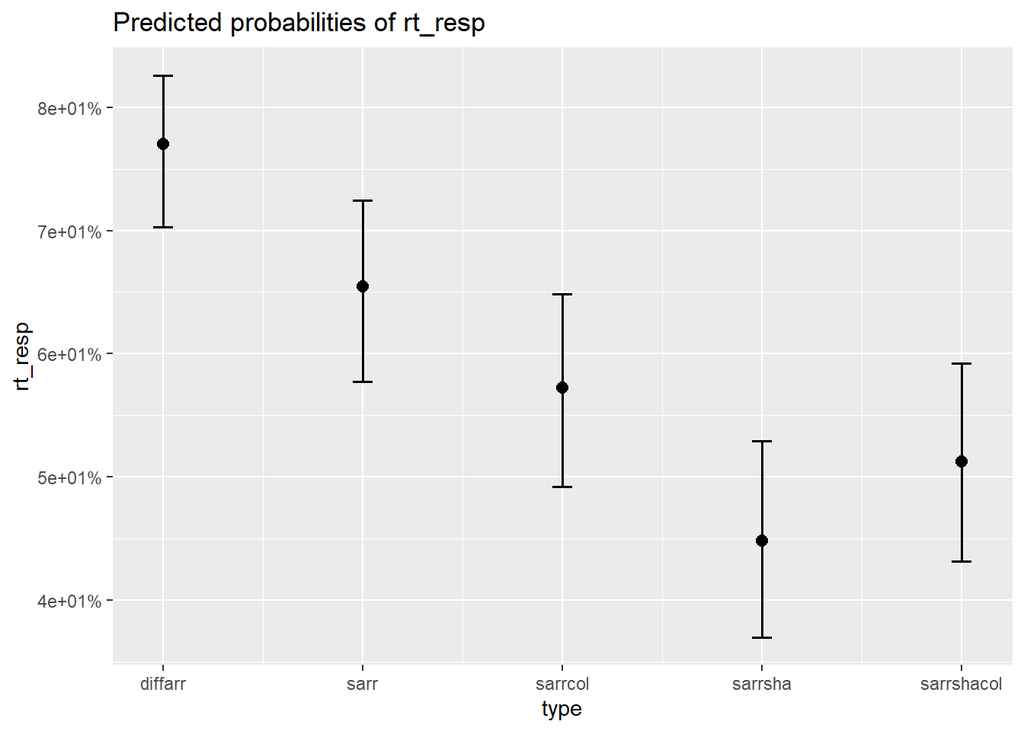

```
## Package `effects` is not available, but needed for `ggeffect()`. Either install package `effects`, or use `ggpredict()`. Calling `ggpredict()` now.FALSE
```

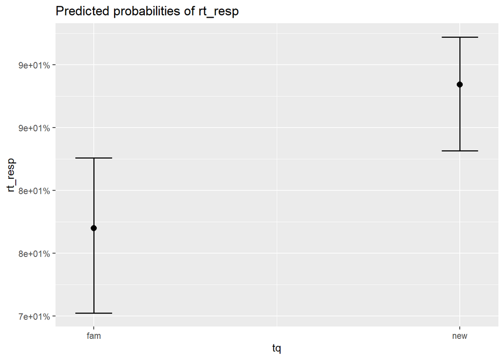

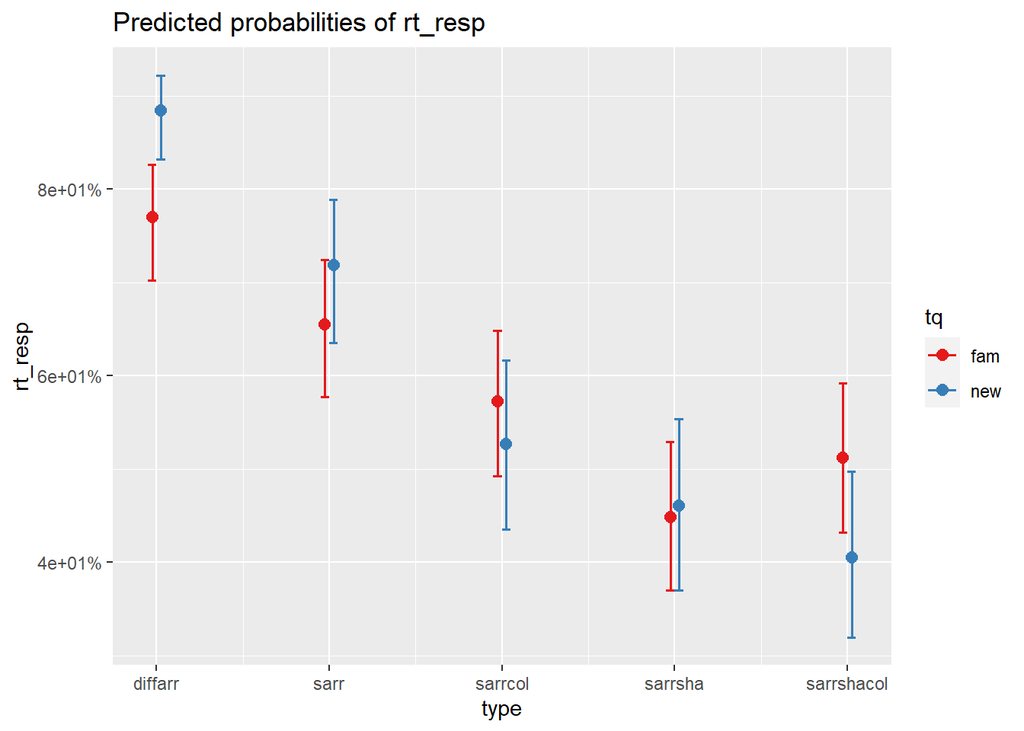

```
## boundary (singular) fit: see ?isSingular
```

```
## Generalized linear mixed model fit by maximum likelihood (Laplace
##   Approximation) [glmerMod]
##  Family: binomial  ( logit )
## Formula: rt_resp ~ DTF * tq + (tq | workerId)
##    Data: tdlmm
##
##      AIC      BIC   logLik deviance df.resid
##   4088.1   4131.0  -2037.0   4074.1     3412
##
## Scaled residuals:
##     Min      1Q  Median      3Q     Max
## -5.5245 -0.8872  0.4054  0.7767  5.8420
##
## Random effects:
##  Groups   Name        Variance Std.Dev. Corr
##  workerId (Intercept) 0.57591  0.7589
##           tqnew       0.02916  0.1708   1.00
## Number of obs: 3419, groups:  workerId, 41
##
## Fixed effects:
##             Estimate Std. Error z value Pr(>|z|)
## (Intercept) -0.18731    0.14656  -1.278 0.201236
## DTF          0.08567    0.01098   7.805 5.95e-15 ***
## tqnew       -0.45695    0.13347  -3.423 0.000618 ***
## DTF:tqnew    0.07850    0.01776   4.421 9.83e-06 ***
## ---
## Signif. codes:  0 '***' 0.001 '**' 0.01 '*' 0.05 '.' 0.1 ' ' 1
##
## Correlation of Fixed Effects:
##           (Intr) DTF    tqnew
## DTF       -0.464
## tqnew     -0.212  0.508
## DTF:tqnew  0.284 -0.617 -0.792
## convergence code: 0
## boundary (singular) fit: see ?isSingular
```

```
## Package `effects` is not available, but needed for `ggeffect()`. Either install package `effects`, or use `ggpredict()`. Calling `ggpredict()` now.FALSE
```

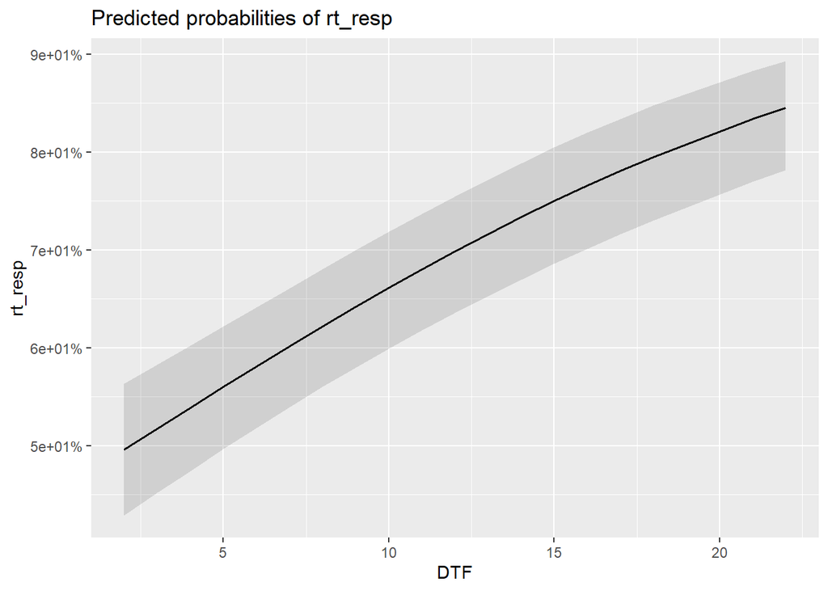

```
## Package `effects` is not available, but needed for `ggeffect()`. Either install package `effects`, or use `ggpredict()`. Calling `ggpredict()` now.FALSE
```

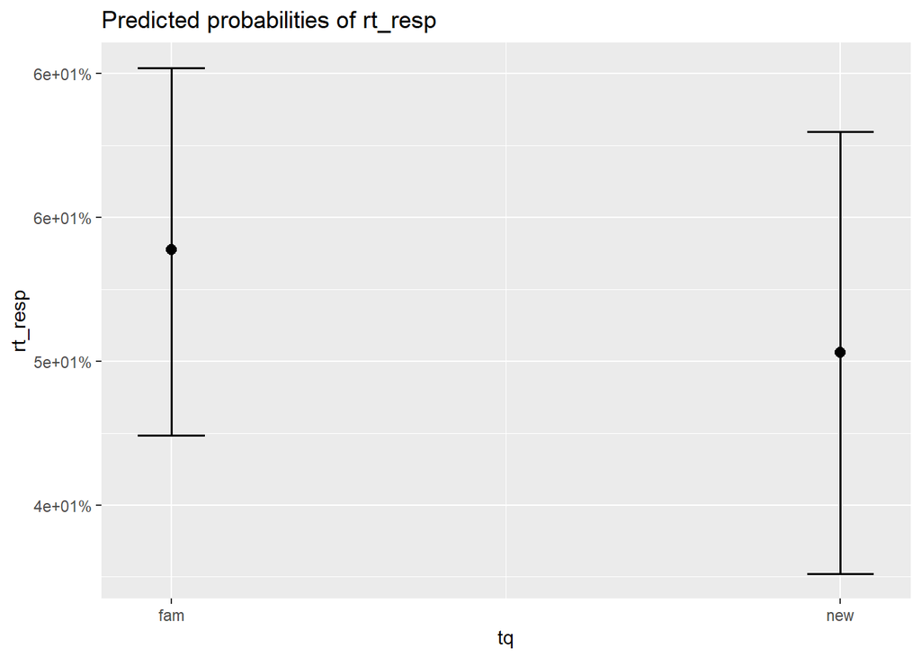

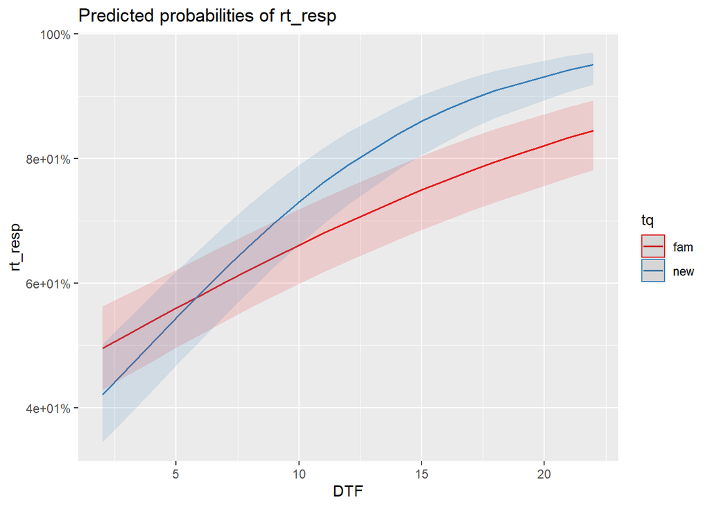

```
## boundary (singular) fit: see ?isSingular
```

```
## Generalized linear mixed model fit by maximum likelihood (Laplace
##   Approximation) [glmerMod]
##  Family: binomial  ( logit )
## Formula: rt_resp ~ DTAF * tq + (tq | workerId)
##    Data: tdlmm
##
##      AIC      BIC   logLik deviance df.resid
##   4101.6   4144.5  -2043.8   4087.6     3412
##
## Scaled residuals:
##     Min      1Q  Median      3Q     Max
## -4.8309 -0.8877  0.4120  0.7744  4.6664
##
## Random effects:
##  Groups   Name        Variance Std.Dev. Corr
##  workerId (Intercept) 0.56650  0.7527
##           tqnew       0.02548  0.1596   1.00
## Number of obs: 3419, groups:  workerId, 41
##
## Fixed effects:
##             Estimate Std. Error z value Pr(>|z|)
## (Intercept) -1.68321    0.28449  -5.917 3.29e-09 ***
## DTAF         0.16122    0.02016   7.996 1.29e-15 ***
## tqnew       -1.40335    0.39684  -3.536 0.000406 ***
## DTAF:tqnew   0.11383    0.03112   3.657 0.000255 ***
## ---
## Signif. codes:  0 '***' 0.001 '**' 0.01 '*' 0.05 '.' 0.1 ' ' 1
##
## Correlation of Fixed Effects:
##            (Intr) DTAF   tqnew
## DTAF       -0.891
## tqnew      -0.566  0.638
## DTAF:tqnew  0.576 -0.647 -0.979
## convergence code: 0
## boundary (singular) fit: see ?isSingular
```

```
## Package `effects` is not available, but needed for `ggeffect()`. Either install package `effects`, or use `ggpredict()`. Calling `ggpredict()` now.FALSE
```

```
## Data were 'prettified'. Consider using `terms="DTAF [all]"` to get smooth plots.
```

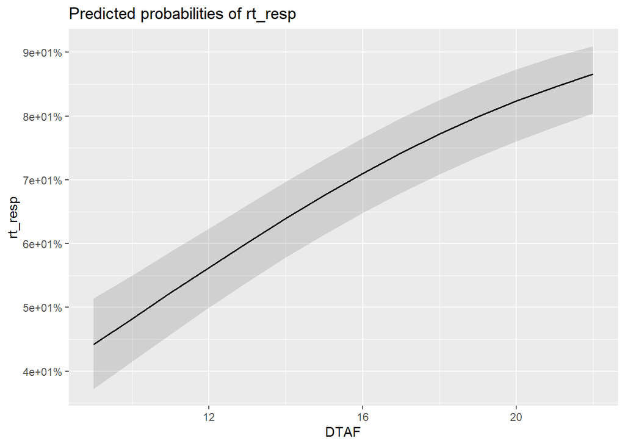

```
## Package `effects` is not available, but needed for `ggeffect()`. Either install package `effects`, or use `ggpredict()`. Calling `ggpredict()` now.FALSE
## Data were 'prettified'. Consider using `terms="DTAF [all]"` to get smooth plots.
```

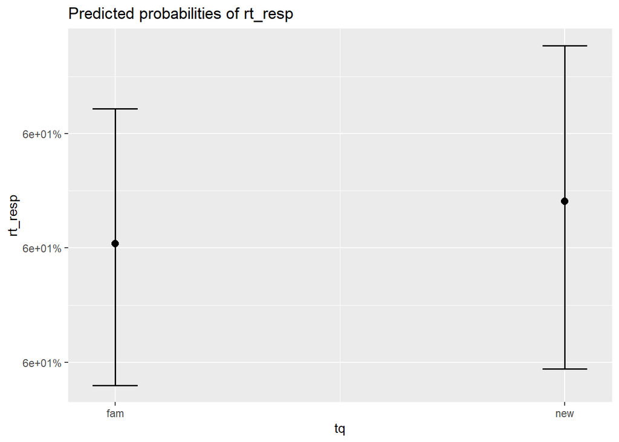

```
## Data were 'prettified'. Consider using `terms="DTAF [all]"` to get smooth plots.
```

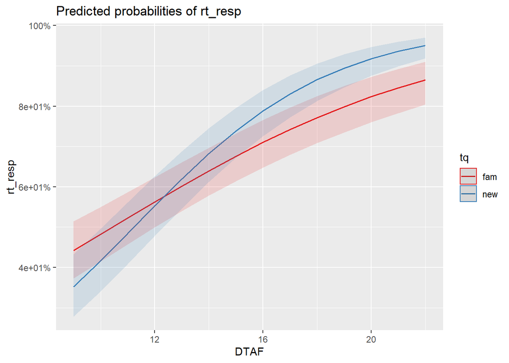

```
## boundary (singular) fit: see ?isSingular
```

```
## Generalized linear mixed model fit by maximum likelihood (Laplace
##   Approximation) [glmerMod]
##  Family: binomial  ( logit )
## Formula: rt_resp ~ DTAN * tq + (tq | workerId)
##    Data: tdlmm
##
##      AIC      BIC   logLik deviance df.resid
##   4141.5   4184.5  -2063.8   4127.5     3412
##
## Scaled residuals:
##     Min      1Q  Median      3Q     Max
## -6.9143 -0.9066  0.4392  0.7667  3.9439
##
## Random effects:
##  Groups   Name        Variance Std.Dev. Corr
##  workerId (Intercept) 0.56780  0.7535
##           tqnew       0.01826  0.1351   1.00
## Number of obs: 3419, groups:  workerId, 41
##
## Fixed effects:
##             Estimate Std. Error z value Pr(>|z|)
## (Intercept) -2.50792    0.39318  -6.379 1.79e-10 ***
## DTAN         0.22635    0.02936   7.710 1.26e-14 ***
## tqnew       -1.68171    0.55873  -3.010  0.00261 **
## DTAN:tqnew   0.13751    0.04393   3.130  0.00175 **
## ---
## Signif. codes:  0 '***' 0.001 '**' 0.01 '*' 0.05 '.' 0.1 ' ' 1
##
## Correlation of Fixed Effects:
##            (Intr) DTAN   tqnew
## DTAN       -0.945
## tqnew      -0.629  0.665
## DTAN:tqnew  0.631 -0.668 -0.990
## convergence code: 0
## boundary (singular) fit: see ?isSingular
```

```
## Package `effects` is not available, but needed for `ggeffect()`. Either install package `effects`, or use `ggpredict()`. Calling `ggpredict()` now.FALSE
```

```
## Data were 'prettified'. Consider using `terms="DTAN [all]"` to get smooth plots.
```

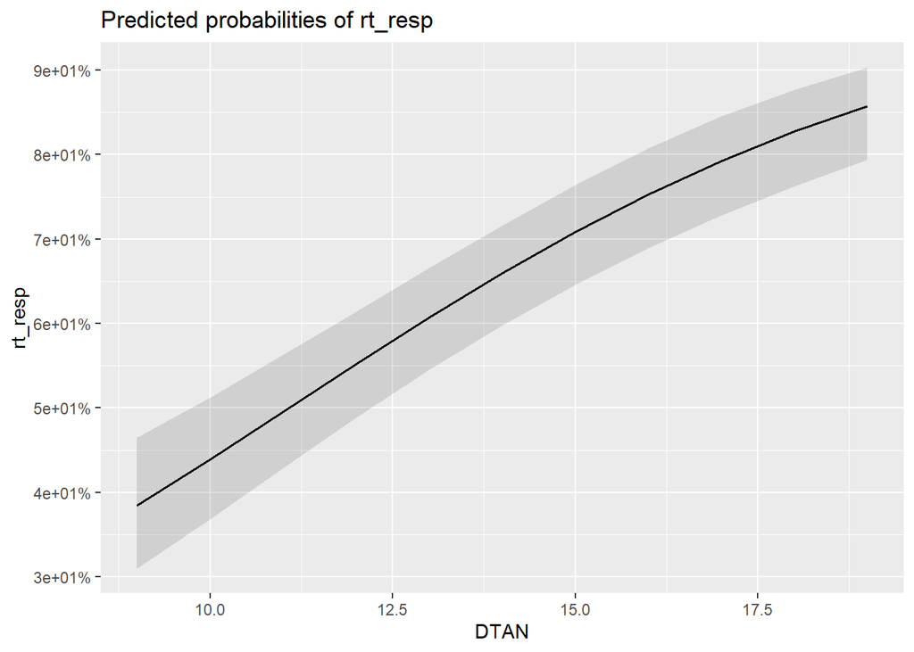

```
## Package `effects` is not available, but needed for `ggeffect()`. Either install package `effects`, or use `ggpredict()`. Calling `ggpredict()` now.FALSE
## Data were 'prettified'. Consider using `terms="DTAN [all]"` to get smooth plots.
```

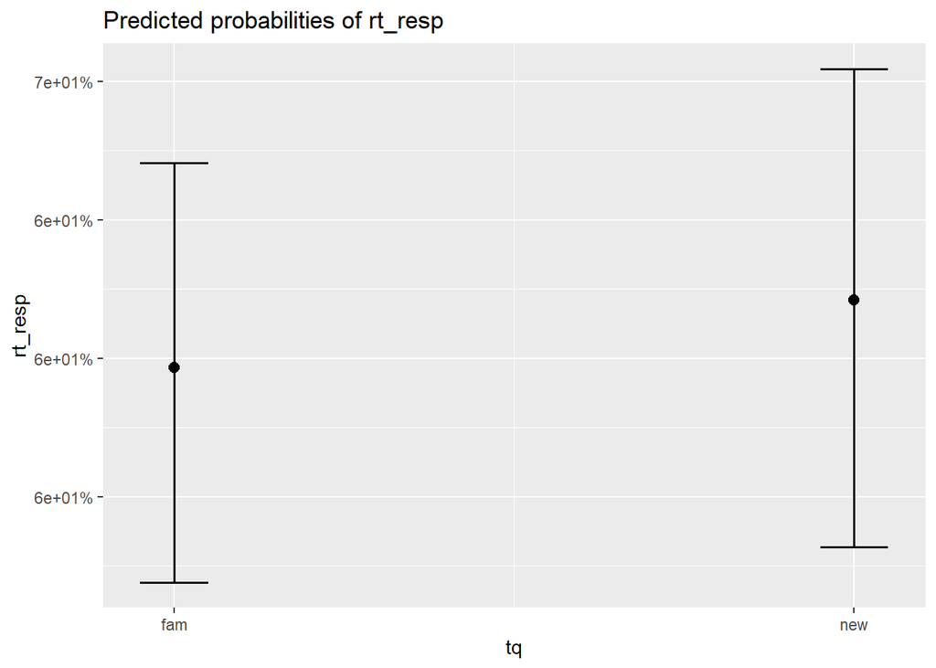

```
## Data were 'prettified'. Consider using `terms="DTAN [all]"` to get smooth plots.
```

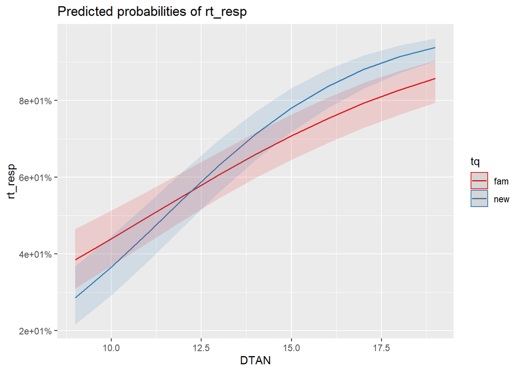

```
## boundary (singular) fit: see ?isSingular
```

```
## Generalized linear mixed model fit by maximum likelihood (Laplace
##   Approximation) [glmerMod]
##  Family: binomial  ( logit )
## Formula: rt_resp ~ DTN_byPhase * tq + (tq | workerId)
##    Data: tdlmm
##
##      AIC      BIC   logLik deviance df.resid
##   4160.1   4203.1  -2073.1   4146.1     3412
##
## Scaled residuals:
##     Min      1Q  Median      3Q     Max
## -6.0351 -0.9096  0.4408  0.7696  3.8745
##
## Random effects:
##  Groups   Name        Variance Std.Dev. Corr
##  workerId (Intercept) 0.56487  0.7516
##           tqnew       0.01695  0.1302   1.00
## Number of obs: 3419, groups:  workerId, 41
##
## Fixed effects:
##                   Estimate Std. Error z value Pr(>|z|)
## (Intercept)       -2.48246    0.40220  -6.172 6.73e-10 ***
## DTN_byPhase        0.21659    0.02906   7.454 9.08e-14 ***
## tqnew             -1.54915    0.56711  -2.732  0.00630 **
## DTN_byPhase:tqnew  0.12192    0.04297   2.838  0.00455 **
## ---
## Signif. codes:  0 '***' 0.001 '**' 0.01 '*' 0.05 '.' 0.1 ' ' 1
##
## Correlation of Fixed Effects:
##             (Intr) DTN_bP tqnew
## DTN_byPhase -0.947
## tqnew       -0.638  0.672
## DTN_byPhs:t  0.641 -0.676 -0.990
## convergence code: 0
## boundary (singular) fit: see ?isSingular
```

```
## Package `effects` is not available, but needed for `ggeffect()`. Either install package `effects`, or use `ggpredict()`. Calling `ggpredict()` now.FALSE
```

```
## Data were 'prettified'. Consider using `terms="DTN_byPhase [all]"` to get smooth plots.
```

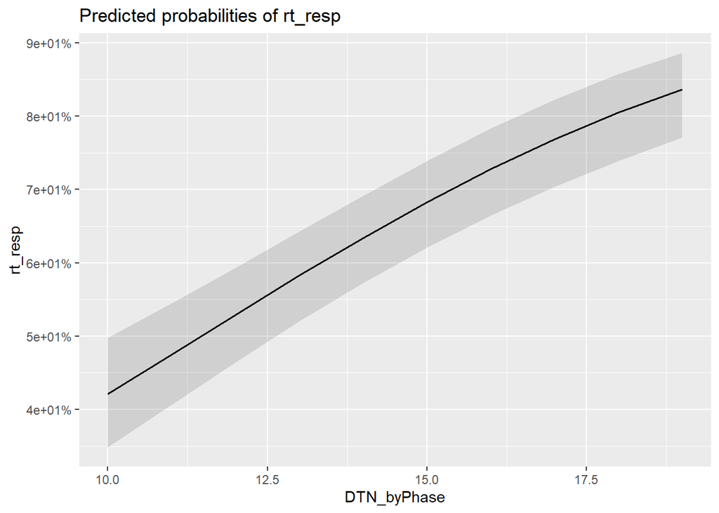

```
## Package `effects` is not available, but needed for `ggeffect()`. Either install package `effects`, or use `ggpredict()`. Calling `ggpredict()` now.FALSE
## Data were 'prettified'. Consider using `terms="DTN_byPhase [all]"` to get smooth plots.
```

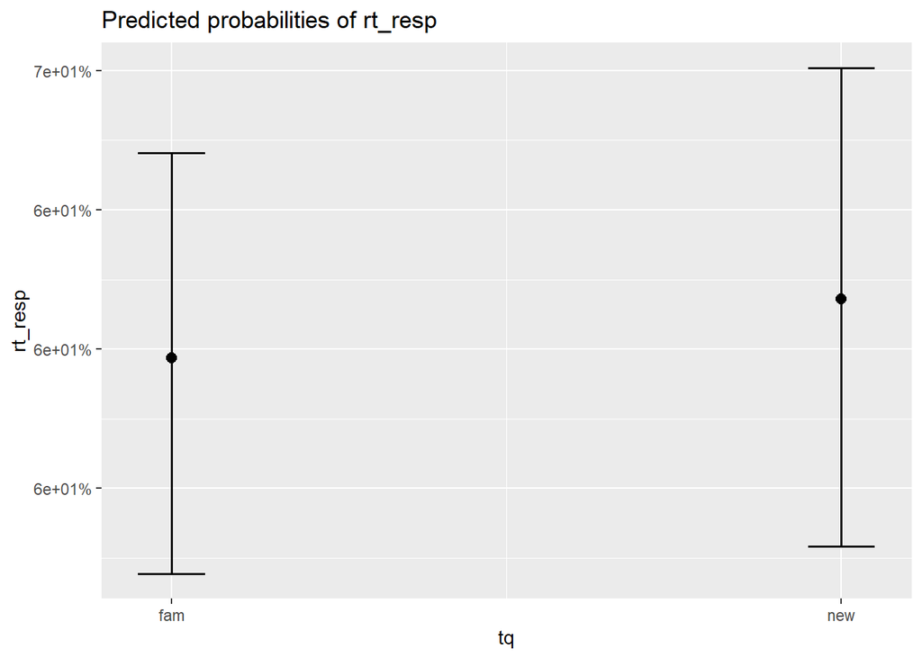

```
## Data were 'prettified'. Consider using `terms="DTN_byPhase [all]"` to get smooth plots.
```

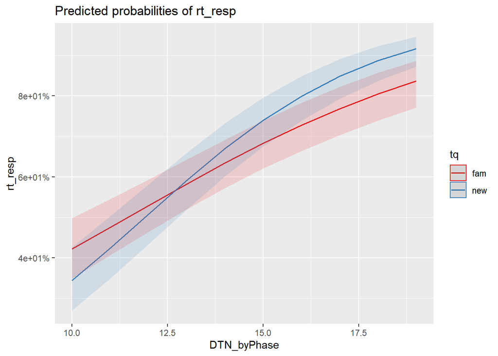

```
## boundary (singular) fit: see ?isSingular
```

```
## Generalized linear mixed model fit by maximum likelihood (Laplace
##   Approximation) [glmerMod]
##  Family: binomial  ( logit )
## Formula: rt_resp ~ DTPPm * tq + (tq | workerId)
##    Data: tdlmm
##
##      AIC      BIC   logLik deviance df.resid
##   4092.2   4135.1  -2039.1   4078.2     3412
##
## Scaled residuals:
##     Min      1Q  Median      3Q     Max
## -5.0333 -0.8868  0.4107  0.7735  4.6904
##
## Random effects:
##  Groups   Name        Variance Std.Dev. Corr
##  workerId (Intercept) 0.57096  0.7556
##           tqnew       0.02457  0.1568   1.00
## Number of obs: 3419, groups:  workerId, 41
##
## Fixed effects:
##             Estimate Std. Error z value Pr(>|z|)
## (Intercept) -2.71151    0.38183  -7.101 1.24e-12 ***
## DTPPm        0.22799    0.02684   8.495  < 2e-16 ***
## tqnew       -1.74463    0.55470  -3.145  0.00166 **
## DTPPm:tqnew  0.13174    0.04115   3.202  0.00137 **
## ---
## Signif. codes:  0 '***' 0.001 '**' 0.01 '*' 0.05 '.' 0.1 ' ' 1
##
## Correlation of Fixed Effects:
##             (Intr) DTPPm  tqnew
## DTPPm       -0.941
## tqnew       -0.607  0.647
## DTPPm:tqnew  0.613 -0.652 -0.989
## convergence code: 0
## boundary (singular) fit: see ?isSingular
```

```
## Package `effects` is not available, but needed for `ggeffect()`. Either install package `effects`, or use `ggpredict()`. Calling `ggpredict()` now.FALSE
```

```
## Data were 'prettified'. Consider using `terms="DTPPm [all]"` to get smooth plots.
```

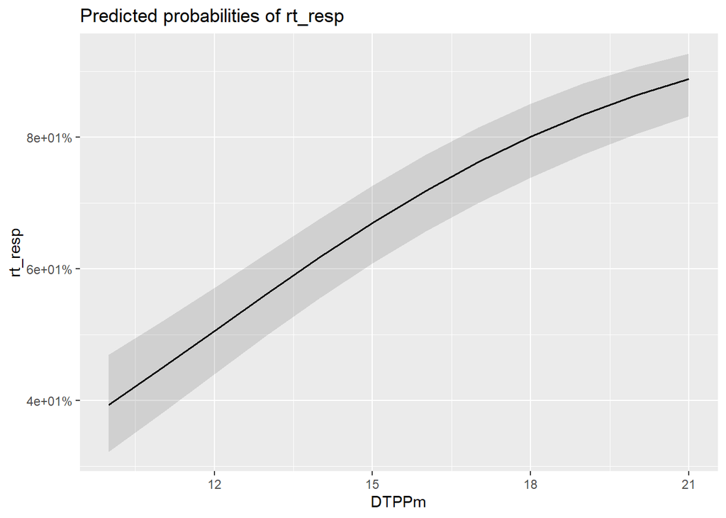

```
## Package `effects` is not available, but needed for `ggeffect()`. Either install package `effects`, or use `ggpredict()`. Calling `ggpredict()` now.FALSE
## Data were 'prettified'. Consider using `terms="DTPPm [all]"` to get smooth plots.
```

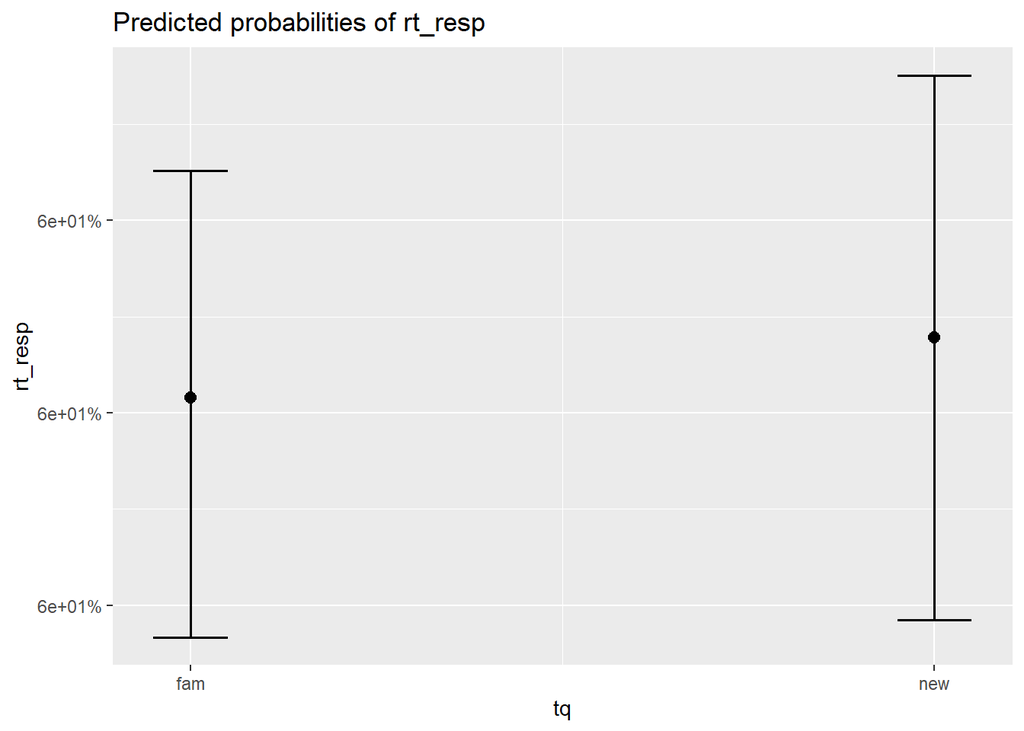

```
## Data were 'prettified'. Consider using `terms="DTPPm [all]"` to get smooth plots.
```

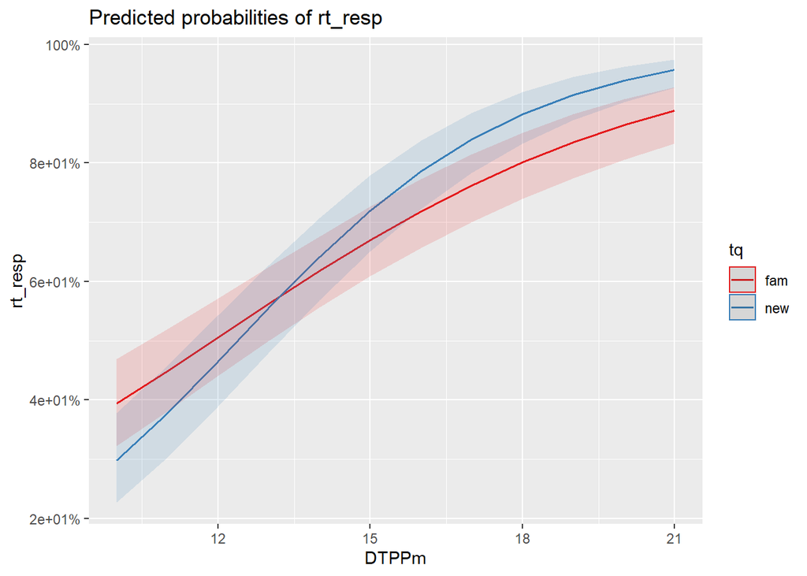

|  | rt_resp |  |  |  | rt_resp |  |  |  | rt_resp |  |  |  | rt_resp |  |  |  | rt_resp |  |  |  | rt_resp |  |  |  |
| --- | --- | --- | --- | --- | --- | --- | --- | --- | --- | --- | --- | --- | --- | --- | --- | --- | --- | --- | --- | --- | --- | --- | --- | --- |
| Predictors | Log-Odds | std. Error | CI | p | Log-Odds | std. Error | CI | p | Log-Odds | std. Error | CI | p | Log-Odds | std. Error | CI | p | Log-Odds | std. Error | CI | p | Log-Odds | std. Error | CI | p |
| (Intercept) | 1.21 | 0.18 | 0.86 – 1.56 | **<0.001** | -0.19 | 0.15 | -0.47 – 0.10 | 0.201 | -1.68 | 0.28 | -2.24 – -1.13 | **<0.001** | -2.51 | 0.39 | -3.28 – -1.74 | **<0.001** | -2.48 | 0.40 | -3.27 – -1.69 | **<0.001** | -2.71 | 0.38 | -3.46 – -1.96 | **<0.001** |
| type [sarr] | -0.57 | 0.18 | -0.92 – -0.22 | **0.001** |  |  |  |  |  |  |  |  |  |  |  |  |  |  |  |  |  |  |  |  |
| type [sarrcol] | -0.92 | 0.17 | -1.26 – -0.58 | **<0.001** |  |  |  |  |  |  |  |  |  |  |  |  |  |  |  |  |  |  |  |  |
| type [sarrsha] | -1.42 | 0.18 | -1.76 – -1.07 | **<0.001** |  |  |  |  |  |  |  |  |  |  |  |  |  |  |  |  |  |  |  |  |
| type [sarrshacol] | -1.16 | 0.17 | -1.50 – -0.82 | **<0.001** |  |  |  |  |  |  |  |  |  |  |  |  |  |  |  |  |  |  |  |  |
| tq [new] | 0.83 | 0.22 | 0.40 – 1.25 | **<0.001** | -0.46 | 0.13 | -0.72 – -0.20 | **0.001** | -1.40 | 0.40 | -2.18 – -0.63 | **<0.001** | -1.68 | 0.56 | -2.78 – -0.59 | **0.003** | -1.55 | 0.57 | -2.66 – -0.44 | **0.006** | -1.74 | 0.55 | -2.83 – -0.66 | **0.002** |
| type [sarr] * tq [new] | -0.53 | 0.27 | -1.06 – 0.01 | 0.053 |  |  |  |  |  |  |  |  |  |  |  |  |  |  |  |  |  |  |  |  |
| type [sarrcol] * tq [new] | -1.01 | 0.27 | -1.54 – -0.48 | **<0.001** |  |  |  |  |  |  |  |  |  |  |  |  |  |  |  |  |  |  |  |  |
| type [sarrsha] * tq [new] | -0.78 | 0.27 | -1.31 – -0.24 | **0.004** |  |  |  |  |  |  |  |  |  |  |  |  |  |  |  |  |  |  |  |  |
| type [sarrshacol] * tq [new] | -1.26 | 0.27 | -1.79 – -0.73 | **<0.001** |  |  |  |  |  |  |  |  |  |  |  |  |  |  |  |  |  |  |  |  |
| DTF |  |  |  |  | 0.09 | 0.01 | 0.06 – 0.11 | **<0.001** |  |  |  |  |  |  |  |  |  |  |  |  |  |  |  |  |
| DTF * tq [new] |  |  |  |  | 0.08 | 0.02 | 0.04 – 0.11 | **<0.001** |  |  |  |  |  |  |  |  |  |  |  |  |  |  |  |  |
| DTAF |  |  |  |  |  |  |  |  | 0.16 | 0.02 | 0.12 – 0.20 | **<0.001** |  |  |  |  |  |  |  |  |  |  |  |  |
| DTAF * tq [new] |  |  |  |  |  |  |  |  | 0.11 | 0.03 | 0.05 – 0.17 | **<0.001** |  |  |  |  |  |  |  |  |  |  |  |  |
| DTAN |  |  |  |  |  |  |  |  |  |  |  |  | 0.23 | 0.03 | 0.17 – 0.28 | **<0.001** |  |  |  |  |  |  |  |  |
| DTAN * tq [new] |  |  |  |  |  |  |  |  |  |  |  |  | 0.14 | 0.04 | 0.05 – 0.22 | **0.002** |  |  |  |  |  |  |  |  |
| DTN_byPhase |  |  |  |  |  |  |  |  |  |  |  |  |  |  |  |  | 0.22 | 0.03 | 0.16 – 0.27 | **<0.001** |  |  |  |  |
| DTN_byPhase * tq [new] |  |  |  |  |  |  |  |  |  |  |  |  |  |  |  |  | 0.12 | 0.04 | 0.04 – 0.21 | **0.005** |  |  |  |  |
| DTPPm |  |  |  |  |  |  |  |  |  |  |  |  |  |  |  |  |  |  |  |  | 0.23 | 0.03 | 0.18 – 0.28 | **<0.001** |
| DTPPm * tq [new] |  |  |  |  |  |  |  |  |  |  |  |  |  |  |  |  |  |  |  |  | 0.13 | 0.04 | 0.05 – 0.21 | **0.001** |
| Random Effects |  |  |  |  |  |  |  |  |  |  |  |  |  |  |  |  |  |  |  |  |  |  |  |  |
| σ<sup>2</sup> | 3.29 |  |  |  | 3.29 |  |  |  | 3.29 |  |  |  | 3.29 |  |  |  | 3.29 |  |  |  | 3.29 |  |  |  |
| τ<sub>00</sub> | 0.58 <sub>workerId</sub> |  |  |  | 0.58 <sub>workerId</sub> |  |  |  | 0.57 <sub>workerId</sub> |  |  |  | 0.57 <sub>workerId</sub> |  |  |  | 0.56 <sub>workerId</sub> |  |  |  | 0.57 <sub>workerId</sub> |  |  |  |
| τ<sub>11</sub> | 0.03 <sub>workerId.tqnew</sub> |  |  |  | 0.03 <sub>workerId.tqnew</sub> |  |  |  | 0.03 <sub>workerId.tqnew</sub> |  |  |  | 0.02 <sub>workerId.tqnew</sub> |  |  |  | 0.02 <sub>workerId.tqnew</sub> |  |  |  | 0.02 <sub>workerId.tqnew</sub> |  |  |  |
| ρ<sub>01</sub> | 1.00 <sub>workerId</sub> |  |  |  | 1.00 <sub>workerId</sub> |  |  |  | 1.00 <sub>workerId</sub> |  |  |  | 1.00 <sub>workerId</sub> |  |  |  | 1.00 <sub>workerId</sub> |  |  |  | 1.00 <sub>workerId</sub> |  |  |  |
| ICC | 0.18 |  |  |  |  |  |  |  | 0.17 |  |  |  |  |  |  |  | 0.17 |  |  |  |  |  |  |  |
| N | 41 <sub>workerId</sub> |  |  |  | 41 <sub>workerId</sub> |  |  |  | 41 <sub>workerId</sub> |  |  |  | 41 <sub>workerId</sub> |  |  |  | 41 <sub>workerId</sub> |  |  |  | 41 <sub>workerId</sub> |  |  |  |
| Observations | 3419 |  |  |  | 3419 |  |  |  | 3419 |  |  |  | 3419 |  |  |  | 3419 |  |  |  | 3419 |  |  |  |
| Marginal R<sup>2</sup> / Conditional R<sup>2</sup> | 0.114 / 0.275 |  |  |  | 0.134 / NA |  |  |  | 0.102 / 0.259 |  |  |  | 0.091 / NA |  |  |  | 0.069 / 0.226 |  |  |  | 0.125 / NA |  |  |  |
| AIC | 4056.418 |  |  |  | 4088.108 |  |  |  | 4101.619 |  |  |  | 4141.552 |  |  |  | 4160.172 |  |  |  | 4092.199 |  |  |  |